# Life Expectancy (Regression Problem)

07-04-2024

## Introduction

Team Members:

Andreas Papadopoulos

Constantinos Constantinou

Foivos Lympouras

Iosif Pintirishis

This research will delve into various determinants of life expectancy, including immunization rates, mortality statistics, economic indicators, social considerations, and additional health-related metrics. Given that the data contains a diverse range of countries, it will facilitate the identification of key factors that negatively affect life expectancy. Consequently, this analysis will enable countries to pinpoint specific areas requiring attention and intervention, in order to provide a roadmap for effectively improving the longevity of their citizens. We will be using data from a period of 2000 to 2015 for 179 countries. Our aim is to predict the life expectancy at birth (response) using the other variables as predictors.

## Load packages

Load the necessary packages that will be used later.

```r
rm(list = ls())

list.of.packages <- c("ggplot2", "dplyr", "MASS", "DescTools", "nortest", "moments", "reshape2",
"mice", "leaps", "corrplot", "GGally", "glmnet", "randomForest", "boot")
new.packages <- list.of.packages[!(list.of.packages %in% installed.packages()[, "Package"])]
# Install them in case they are not already
if (length(new.packages)) install.packages(new.packages)
# Load packages
invisible(lapply(list.of.packages, library, character.only = TRUE))
```

## Functions

```r
change_data <- function(data, name_the_var){
  # Function to get the columns we need from some files which they have the same structure
  data <- dplyr::select(data, Location, Period, Value)
  names(data)[names(data) == "Location"] <- "Country"
  names(data)[names(data) == "Period"] <- "Year"
  names(data)[names(data) == "Value"] <- name_the_var
  return(data)
}

change_country_names <- function(data) {
  # Function in order to have the same Country names in the files that we want to join
  data %>%
    mutate(Country = case_when(
      Country == "Democratic Republic of the Congo" ~ "Congo, Dem. Rep.",
      Country == "Côte d’Ivoire" ~ "Cote d'Ivoire",
      Country == "Micronesia (Federated States of)" ~ "Micronesia, Fed. Sts.",
      Country == "Congo" ~ "Congo, Rep.",
      Country == "Gambia" ~ "Gambia, The",
      Country == "Yemen" ~ "Yemen, Rep.",
      Country == "United Republic of Tanzania" ~ "Tanzania",
      Country == "Lao People's Democratic Republic" ~ "Lao PDR",
      Country == "Egypt" ~ "Egypt, Arab Rep.",
      Country == "Bolivia (Plurinational State of)" ~ "Bolivia",
      Country == "Democratic People's Republic of Korea" ~ "Korea, Dem. People's Rep.",
      Country == "Bahamas" ~ "Bahamas, The",
      Country == "Saint Vincent and the Grenadines" ~ "St. Vincent and the Grenadines",
      Country == "Republic of Moldova" ~ "Moldova",
      Country == "Venezuela (Bolivarian Republic of)" ~ "Venezuela, RB",
      Country == "Kyrgyzstan" ~ "Kyrgyz Republic",
      Country == "Saint Lucia" ~ "St. Lucia",
      Country == "The former Yugoslav Republic of Macedonia" ~ "North Macedonia",
      Country == "Iran (Islamic Republic of)" ~ "Iran, Islamic Rep.",
      Country == "Slovakia" ~ "Slovak Republic",
      Country == "United States of America" ~ "United States",
      Country == "Türkiye" ~ "Turkiye",
      Country == "United Kingdom of Great Britain and Northern Ireland" ~ "United Kingdom",
      Country == "Republic of Korea" ~ "Korea, Rep.",
      TRUE ~ Country
    ))
}

predict.regsubsets <- function(object, newdata, id, ...) {
  # Predict method for regsubsets()
  form <- as.formula(object$call[[2]])
  mat <- model.matrix(form, newdata)
  coefi <- coef(object, id = id)
  xvars <- names(coefi)
  mat[, xvars] %*% coefi
 }
```

## Import data

The data comes from many sources. Our main file is the Life-Expectancy-Data-Update, which is from Kaggle([Life Expectancy dataset](https://www.kaggle.com/datasets/lashagoch/life-expectancy-who-updated/data?fbclid=IwAR15yFIdHSWyhTXbcX38lE2By0BevxK94OjBuzE4EceieQ5Ckp7Iyw4M76c)). There are some features that we decided to replace from the orginal source files in order to avoid any wrong inputs. Thus, the features Adult mortality, Alcohol, Diptheria, HepatitisB, Measles, Polio and Mean_BMI come from The Global Health Observatory (GHO) data repository under World Health Organization (WHO) which keeps track of the health status as well as many other related factors for all countries. The Population and GDP per capita are from databank.worldbank.

```r
# Import data
life_data <- read.csv("Life-Expectancy-Data-Updated.csv")
life_data <- dplyr::select(life_data, Region, Country, Year, Infant_deaths, Under_five_deaths,
                           Thinness_ten_nineteen_years, Thinness_five_nine_years, Schooling,
                           Incidents_HIV,Economy_status_Developed, Economy_status_Developing,
                           Life_expectancy)

adult_mort_data <- read.csv("Adult_mortality_inputs.csv")
adult_mort_data <- subset(adult_mort_data, Dim1 == "Both sexes")
adult_mort_data <- change_data(adult_mort_data, "Adult_mortality")

alcohol_data <- read.csv("Alcohol_inputs.csv")
alcohol_data <- subset(alcohol_data, Dim1ValueCode == "ALCOHOLTYPE_SA_TOTAL")
alcohol_data <- change_data(alcohol_data, "Alcohol")

diphtheria_data <- read.csv("Diphtheria_inputs.csv")
diphtheria_data <- change_data(diphtheria_data, "Diphtheria")

hepatitisB_data <- read.csv("HepatitisB_inputs.csv")
hepatitisB_data <- change_data(hepatitisB_data, "HepatitisB")

measles_data <- read.csv("Measles_inputs.csv")
measles_data <- change_data(measles_data, "Measles")

polio_data <- read.csv("Polio_inputs.csv")
polio_data <- change_data(polio_data, "Polio")

Mean_BMI_data <- read.csv("Mean_BMI_inputs.csv")
Mean_BMI_data <- subset(Mean_BMI_data, Dim1 == "Both sexes")
Mean_BMI_data <- dplyr::select(Mean_BMI_data, Location, Period, FactValueNumeric)
names(Mean_BMI_data)[names(Mean_BMI_data) == "Location"] <- "Country"
names(Mean_BMI_data)[names(Mean_BMI_data) == "Period"] <- "Year"
names(Mean_BMI_data)[names(Mean_BMI_data) == "FactValueNumeric"] <- "Mean_BMI"

Population_data <- read.csv("Population_inputs.csv")

# Melt from reshape2
Population_data <- melt(Population_data, id.vars = c("Series.Name", "Series.Code","Country.Name", "Country.Code"),
                        variable.name = "Year", value.name = "Population")
Population_data <- dplyr::select(Population_data, Country.Name, Year, Population)
names(Population_data)[names(Population_data) == "Country.Name"] <- "Country"

Population_data$Year <- gsub("X(\\d{4})\\..YR\\d{4}.", "\\1", Population_data$Year)
Population_data$Year <- as.numeric(Population_data$Year)

GDP_data <- read.csv("GDP_inputs.csv")
# Melt from reshape2
GDP_data <- melt(GDP_data, id.vars = c("Series.Name", "Series.Code","Country.Name", "Country.Code"),
                 variable.name = "Year", value.name = "GDP")
GDP_data <- dplyr::select(GDP_data, Country.Name, Year, GDP)
names(GDP_data)[names(GDP_data) == "Country.Name"] <- "Country"

GDP_data$Year <- gsub("X(\\d{4})\\..YR\\d{4}.", "\\1", GDP_data$Year)
GDP_data$Year <- as.numeric(GDP_data$Year)


life_data <- left_join(life_data, adult_mort_data, by = c("Country", "Year"))
life_data <- left_join(life_data, alcohol_data, by = c("Country", "Year"))
life_data <- left_join(life_data, diphtheria_data, by = c("Country", "Year"))
life_data <- left_join(life_data, hepatitisB_data, by = c("Country", "Year"))
life_data <- left_join(life_data, measles_data, by = c("Country", "Year"))
life_data <- left_join(life_data, polio_data, by = c("Country", "Year"))
life_data <- left_join(life_data, Mean_BMI_data, by = c("Country", "Year"))
life_data <- left_join(life_data, Population_data, by = c("Country", "Year"))
life_data <- left_join(life_data, GDP_data, by = c("Country", "Year"))

names(life_data)
```

```
##  [1] "Region"                      "Country"
##  [3] "Year"                        "Infant_deaths"
##  [5] "Under_five_deaths"           "Thinness_ten_nineteen_years"
##  [7] "Thinness_five_nine_years"    "Schooling"
##  [9] "Incidents_HIV"               "Economy_status_Developed"
## [11] "Economy_status_Developing"   "Life_expectancy"
## [13] "Adult_mortality"             "Alcohol"
## [15] "Diphtheria"                  "HepatitisB"
## [17] "Measles"                     "Polio"
## [19] "Mean_BMI"                    "Population"
## [21] "GDP"
```

- `Region` and `Country`: Categorical variables that provide geographic classification for comparative regional analysis.
- `Economy_status_Developed`and `Economy_status_Developing`: Encoded variables stating if the country is Developed or Developing.
- `Year`
- `Infant_deaths` and `Under_five_deaths`: Quantitative measures of child mortality, reflecting the quality of pediatric healthcare and general health conditions (infant and children under five per 1000 population).
- `Adult_mortality`: Indicates the probability of dying between the ages of 15 and 60 per 1000 individuals, a marker of adult health in the population.
- `Alcohol`: Records per capita (15+) consumption of alcohol (in litres of pure alcohol), a factor with known health implications.
- `HepatitisB`, `Diphtheria`, `Polio`: These variables represent immunization coverage rates among 1-year-olds for various diseases, indicating the reach and effectiveness of public health immunization programs.
- `Measles`: Percentage coverage of the measles vaccine among 1-year-olds , crucial for preventing outbreaks.
- `Mean_BMI`: Provides an age-standardized estimate of the population’s average body mass index, relating to nutritional status and health risks.
- `Incidents_HIV`: Reflects the rate of new HIV cases (per 1,000 uninfected population ages 15-49).
- `Thinness_five_nine_years` and `Thinness_ten_nineteen_years`: Represent the prevalence of underweight among children and adolescents, indicating potential nutritional deficiencies.
- `Schooling`: Measures the average number of years of education received for individuals aged 15-64, a socio-economic factor linked to health literacy.
- `GDP`: Stands for Gross Domestic Product per capita, an economic indicator that correlates with a country’s health infrastructure and services (current US$).
- `Population`: Population of each country for a specific year

## Data pre-processing

Data pre-processing

```r
nrow(life_data)
```

```
## [1] 2864
```

```r
summary(life_data)
```

```
##     Region            Country               Year      Infant_deaths
##  Length:2864        Length:2864        Min.   :2000   Min.   :  1.80
##  Class :character   Class :character   1st Qu.:2004   1st Qu.:  8.10
##  Mode  :character   Mode  :character   Median :2008   Median : 19.60
##                                        Mean   :2008   Mean   : 30.36
##                                        3rd Qu.:2011   3rd Qu.: 47.35
##                                        Max.   :2015   Max.   :138.10
##
##  Under_five_deaths Thinness_ten_nineteen_years Thinness_five_nine_years
##  Min.   :  2.300   Min.   : 0.100              Min.   : 0.1
##  1st Qu.:  9.675   1st Qu.: 1.600              1st Qu.: 1.6
##  Median : 23.100   Median : 3.300              Median : 3.4
##  Mean   : 42.938   Mean   : 4.866              Mean   : 4.9
##  3rd Qu.: 66.000   3rd Qu.: 7.200              3rd Qu.: 7.3
##  Max.   :224.900   Max.   :27.700              Max.   :28.6
##
##    Schooling      Incidents_HIV     Economy_status_Developed
##  Min.   : 1.100   Min.   : 0.0100   Min.   :0.0000
##  1st Qu.: 5.100   1st Qu.: 0.0800   1st Qu.:0.0000
##  Median : 7.800   Median : 0.1500   Median :0.0000
##  Mean   : 7.632   Mean   : 0.8943   Mean   :0.2067
##  3rd Qu.:10.300   3rd Qu.: 0.4600   3rd Qu.:0.0000
##  Max.   :14.100   Max.   :21.6800   Max.   :1.0000
##
##  Economy_status_Developing Life_expectancy Adult_mortality    Alcohol
##  Min.   :0.0000            Min.   :39.40   Min.   : 50.0   Min.   : 0.000
##  1st Qu.:1.0000            1st Qu.:62.70   1st Qu.:103.0   1st Qu.: 1.130
##  Median :1.0000            Median :71.40   Median :161.0   Median : 3.990
##  Mean   :0.7933            Mean   :68.86   Mean   :193.6   Mean   : 4.793
##  3rd Qu.:1.0000            3rd Qu.:75.40   3rd Qu.:254.2   3rd Qu.: 7.707
##  Max.   :1.0000            Max.   :83.80   Max.   :697.0   Max.   :17.870
##                                            NA's   :368     NA's   :390
##    Diphtheria      HepatitisB       Measles          Polio
##  Min.   :19.00   Min.   : 2.00   Min.   :16.00   Min.   : 8.00
##  1st Qu.:82.00   1st Qu.:81.00   1st Qu.:79.00   1st Qu.:81.00
##  Median :93.00   Median :92.00   Median :92.00   Median :93.00
##  Mean   :86.31   Mean   :85.22   Mean   :85.26   Mean   :86.43
##  3rd Qu.:97.00   3rd Qu.:97.00   3rd Qu.:96.00   3rd Qu.:97.00
##  Max.   :99.00   Max.   :99.00   Max.   :99.00   Max.   :99.00
##  NA's   :376     NA's   :855     NA's   :376     NA's   :378
##     Mean_BMI      Population            GDP
##  Min.   :19.80   Length:2864        Length:2864
##  1st Qu.:23.30   Class :character   Class :character
##  Median :25.50   Mode  :character   Mode  :character
##  Mean   :24.99
##  3rd Qu.:26.40
##  Max.   :32.10
##  NA's   :368
```

```r
str(life_data) # Structure of the dataset
```

```
## 'data.frame':    2864 obs. of  21 variables:
##  $ Region                     : chr  "Middle East" "European Union" "Asia" "South America" ...
##  $ Country                    : chr  "Turkiye" "Spain" "India" "Guyana" ...
##  $ Year                       : num  2015 2015 2007 2006 2012 ...
##  $ Infant_deaths              : num  11.1 2.7 51.5 32.8 3.4 9.8 6.6 8.7 22 15.3 ...
##  $ Under_five_deaths          : num  13 3.3 67.9 40.5 4.3 11.2 8.2 10.1 26.1 17.8 ...
##  $ Thinness_ten_nineteen_years: num  4.9 0.6 27.1 5.7 1.2 2 2.3 2.3 4 2.9 ...
##  $ Thinness_five_nine_years   : num  4.8 0.5 28 5.5 1.1 1.9 2.3 2.3 3.9 3.1 ...
##  $ Schooling                  : num  7.8 9.7 5 7.9 12.8 7.9 12 10.2 9.6 10.9 ...
##  $ Incidents_HIV              : num  0.08 0.09 0.13 0.79 0.08 0.16 0.08 0.08 0.13 0.43 ...
##  $ Economy_status_Developed   : int  0 1 0 0 1 0 0 1 0 0 ...
##  $ Economy_status_Developing  : int  1 0 1 1 0 1 1 0 1 1 ...
##  $ Life_expectancy            : num  76.5 82.8 65.4 67 81.7 78.2 71.2 71.2 71.9 68.7 ...
##  $ Adult_mortality            : int  NA 58 204 267 58 104 208 193 131 NA ...
##  $ Alcohol                    : num  NA 10.35 1.57 5.68 2.89 ...
##  $ Diphtheria                 : int  NA 97 64 93 94 89 97 99 99 NA ...
##  $ HepatitisB                 : int  NA 97 6 93 97 88 97 NA 97 NA ...
##  $ Measles                    : int  NA 96 70 90 96 90 98 99 99 NA ...
##  $ Polio                      : int  NA 97 67 92 94 89 97 99 97 NA ...
##  $ Mean_BMI                   : num  NA 26 21.2 25.3 27 26.4 26.2 25.9 27.9 NA ...
##  $ Population                 : chr  "78218479" "46444832" "1189691809" "758367" ...
##  $ GDP                        : chr  "11049.9951100942" "25754.36102944" "1022.73246704551" "3138.08220913067" ...
```

```r
# Create a new column of the Economy Status
life_data$Economy_status <- ifelse(life_data$Economy_status_Developed == 1, "Developed",
                                   ifelse(life_data$Economy_status_Developing == 1, "Developing",
                                          NA))
life_data$Economy_status <- as.factor(life_data$Economy_status)
# Change the types of Population and GDP
life_data$Population <- as.numeric(life_data$Population)
life_data$GDP <- as.numeric(life_data$GDP)
# Check for missing values
colSums(is.na(life_data))
```

```
##                      Region                     Country
##                           0                           0
##                        Year               Infant_deaths
##                           0                           0
##           Under_five_deaths Thinness_ten_nineteen_years
##                           0                           0
##    Thinness_five_nine_years                   Schooling
##                           0                           0
##               Incidents_HIV    Economy_status_Developed
##                           0                           0
##   Economy_status_Developing             Life_expectancy
##                           0                           0
##             Adult_mortality                     Alcohol
##                         368                         390
##                  Diphtheria                  HepatitisB
##                         376                         855
##                     Measles                       Polio
##                         376                         378
##                    Mean_BMI                  Population
##                         368                          16
##                         GDP              Economy_status
##                          37                           0
```

There are some countries which they have different names in the Global Health Observatory (GHO) data repository compare to our main file.

```r
unique(life_data$Country[is.na(life_data$Polio)])
```

```
##  [1] "Turkiye"                        "Moldova"
##  [3] "Bahamas, The"                   "Congo, Rep."
##  [5] "Gambia, The"                    "Kyrgyz Republic"
##  [7] "Yemen, Rep."                    "St. Vincent and the Grenadines"
##  [9] "Micronesia, Fed. Sts."          "Congo, Dem. Rep."
## [11] "Bolivia"                        "Vietnam"
## [13] "Egypt, Arab Rep."               "Tanzania"
## [15] "Cote d'Ivoire"                  "St. Lucia"
## [17] "Slovak Republic"                "Venezuela, RB"
## [19] "Iran, Islamic Rep."             "Lao PDR"
## [21] "United States"                  "United Kingdom"
## [23] "Montenegro"                     "Canada"
## [25] "North Macedonia"                "Timor-Leste"
```

```r
unique(life_data$Country[is.na(life_data$Alcohol)])
```

```
##  [1] "Turkiye"                        "Moldova"
##  [3] "Bahamas, The"                   "Congo, Rep."
##  [5] "Gambia, The"                    "Kyrgyz Republic"
##  [7] "Yemen, Rep."                    "St. Vincent and the Grenadines"
##  [9] "Micronesia, Fed. Sts."          "Afghanistan"
## [11] "Congo, Dem. Rep."               "Bolivia"
## [13] "Vietnam"                        "Egypt, Arab Rep."
## [15] "Serbia"                         "Tanzania"
## [17] "Cote d'Ivoire"                  "St. Lucia"
## [19] "Slovak Republic"                "Venezuela, RB"
## [21] "Iran, Islamic Rep."             "Lao PDR"
## [23] "United States"                  "United Kingdom"
## [25] "Montenegro"                     "Canada"
## [27] "North Macedonia"
```

Using the function that we created in the Functions section, we change the names of these Countries and we join again our datasets.

```r
polio_data <- change_country_names(polio_data)
measles_data <- change_country_names(measles_data)
adult_mort_data <- change_country_names(adult_mort_data)
alcohol_data <- change_country_names(alcohol_data)
diphtheria_data <- change_country_names(diphtheria_data)
hepatitisB_data <- change_country_names(hepatitisB_data)
Mean_BMI_data <- change_country_names(Mean_BMI_data)

life_data <- dplyr::select(life_data, -Polio, -Measles, -Adult_mortality,
                           -Alcohol, -Diphtheria, -HepatitisB,
                           -Mean_BMI)
life_data <- left_join(life_data, polio_data, by = c("Country", "Year"))
life_data <- left_join(life_data, measles_data, by = c("Country", "Year"))
life_data <- left_join(life_data, adult_mort_data, by = c("Country", "Year"))
life_data <- left_join(life_data, alcohol_data, by = c("Country", "Year"))
life_data <- left_join(life_data, diphtheria_data, by = c("Country", "Year"))
life_data <- left_join(life_data, hepatitisB_data, by = c("Country", "Year"))
life_data <- left_join(life_data, Mean_BMI_data, by = c("Country", "Year"))
colSums(is.na(life_data))
```

```
##                      Region                     Country
##                           0                           0
##                        Year               Infant_deaths
##                           0                           0
##           Under_five_deaths Thinness_ten_nineteen_years
##                           0                           0
##    Thinness_five_nine_years                   Schooling
##                           0                           0
##               Incidents_HIV    Economy_status_Developed
##                           0                           0
##   Economy_status_Developing             Life_expectancy
##                           0                           0
##                  Population                         GDP
##                          16                          37
##              Economy_status                       Polio
##                           0                          26
##                     Measles             Adult_mortality
##                          24                          16
##                     Alcohol                  Diphtheria
##                          38                          24
##                  HepatitisB                    Mean_BMI
##                         550                          16
```

Check the percentages of the missing data for our variables.

```r
# Percentage of missing data for GDP
sum(is.na(life_data$GDP))*100/nrow(life_data)
```

```
## [1] 1.291899
```

We have only 1.29% missing values for GDP. Therefore, all the columns with number of missing values less than 37 are fine as it is a small percentage. Let’s check for HepatitisB.

```r
sum(is.na(life_data$HepatitisB))*100/nrow(life_data)
```

```
## [1] 19.20391
```

We have 19.2% of missing values for HepatitisB. We usually remove the feature if the missing values are above 10%, but we are going to keep it for now and if it is important predictor after feature selection then we will fit our model with and without HepatitisB.

Many of our data have missing values. We assume that these data follow the Missing Completely at Random (MCAR) mechanism, meaning that the missingness of data is completely random and does not depend on any observed or unobserved data. Due to the big percentage of missing data for HepatitisB we choose to fill the missing values of HepatitisB using Predictive Mean Matching from mice package. Predictive Mean Matching (PMM) is a method for imputing missing values that is widely used in statistical analysis, particularly when dealing with continuous variables. It is a non-parametric imputation technique that falls under the umbrella of multiple imputation methods. The core idea behind PMM is to impute missing values by matching them with observed (non-missing) values from similar cases. For a better imputation we will use the ‘pmm’ in a scaled dataset. As a result our variable HepatitisB will be in a scaled form.

```r
scaled_dataset <- scale(life_data[, c("Infant_deaths", "Under_five_deaths",
                                      "Thinness_ten_nineteen_years", "Thinness_five_nine_years",
                                      "Schooling", "Incidents_HIV",
                                      "Population", "GDP", "Polio", "Measles", "Adult_mortality",
                                      "Alcohol", "Diphtheria", "HepatitisB", "Mean_BMI")])
tempData <- mice(scaled_dataset, m = 4, maxit = 30, method = 'pmm', seed = 48, printFlag = FALSE)

scaled_dataset <- data.frame(scaled_dataset)
life_data$HepatitisB <- scaled_dataset$HepatitisB
life_data$HepatitisB <- complete(tempData, 1)$HepatitisB

colSums(is.na(life_data))
```

```
##                      Region                     Country
##                           0                           0
##                        Year               Infant_deaths
##                           0                           0
##           Under_five_deaths Thinness_ten_nineteen_years
##                           0                           0
##    Thinness_five_nine_years                   Schooling
##                           0                           0
##               Incidents_HIV    Economy_status_Developed
##                           0                           0
##   Economy_status_Developing             Life_expectancy
##                           0                           0
##                  Population                         GDP
##                          16                          37
##              Economy_status                       Polio
##                           0                          26
##                     Measles             Adult_mortality
##                          24                          16
##                     Alcohol                  Diphtheria
##                          38                          24
##                  HepatitisB                    Mean_BMI
##                           0                          16
```

```r
# Remove unnecessary dataframes
rm(adult_mort_data, alcohol_data, diphtheria_data, hepatitisB_data,
   measles_data, polio_data, Mean_BMI_data, Population_data,
   GDP_data, tempData)
```

In addressing the small percentage of missing values within our dataset for the other variables who have missing values, we choose to impute using the median of the training set to maintain the integrity of the validation process and prevent data leakage. The median is a robust measure of central tendency that is less influenced by outliers and skewed distributions, making it particularly suitable for our dataset as we are going to see later in our Exploratory Data Analysis (EDA). By using only the training set for the imputation, we ensure that our model remains uninformed by the test set, preserving the validity of our predictive performance assessments.

```r
# Split the data into training and test sets based on the year
train_set <- life_data[life_data$Year >= 2000 & life_data$Year <= 2012, ]
test_set <- life_data[life_data$Year >= 2013 & life_data$Year <= 2015, ]
# Let's see the proportion of train and test sets
nrow(train_set)*100/nrow(life_data) # 81.25%
```

```
## [1] 81.25
```

```r
nrow(test_set)*100/nrow(life_data) # 18.75%
```

```
## [1] 18.75
```

The division of our dataset into training and test sets has yielded a nearly ideal ratio of 81.25% to 18.75%, which is close to the preferred 80-20 split commonly used in model validation.

```r
# Filling the missing values using the Median of the train_set
median_pop <- median(train_set$Population, na.rm = TRUE)
train_set$Population[is.na(train_set$Population)] <- median_pop
test_set$Population[is.na(test_set$Population)] <- median_pop

median_GDP <- median(train_set$GDP, na.rm = TRUE)
train_set$GDP[is.na(train_set$GDP)] <- median_GDP
test_set$GDP[is.na(test_set$GDP)] <- median_GDP

median_polio <- median(train_set$Polio, na.rm = TRUE)
train_set$Polio[is.na(train_set$Polio)] <- median_polio
test_set$Polio[is.na(test_set$Polio)] <- median_polio

median_Measles <- median(train_set$Measles, na.rm = TRUE)
train_set$Measles[is.na(train_set$Measles)] <- median_Measles
test_set$Measles[is.na(test_set$Measles)] <- median_Measles

median_adult_mort <- median(train_set$Adult_mortality, na.rm = TRUE)
train_set$Adult_mortality[is.na(train_set$Adult_mortality)] <- median_adult_mort
test_set$Adult_mortality[is.na(test_set$Adult_mortality)] <- median_adult_mort

median_alcohol <- median(train_set$Alcohol, na.rm = TRUE)
train_set$Alcohol[is.na(train_set$Alcohol)] <- median_alcohol
test_set$Alcohol[is.na(test_set$Alcohol)] <- median_alcohol

median_diph <- median(train_set$Diphtheria, na.rm = TRUE)
train_set$Diphtheria[is.na(train_set$Diphtheria)] <- median_diph
test_set$Diphtheria[is.na(test_set$Diphtheria)] <- median_diph

median_bmi <- median(train_set$Mean_BMI, na.rm = TRUE)
train_set$Mean_BMI[is.na(train_set$Mean_BMI)] <- median_bmi
test_set$Mean_BMI[is.na(test_set$Mean_BMI)] <- median_bmi
rm(median_pop, median_GDP, median_polio, median_Measles, median_adult_mort, median_alcohol, median_diph, median_bmi)

life_data <- rbind(train_set, test_set)
sum(is.na(life_data)) # No missing values
```

```
## [1] 0
```

## Exploratory Data Analysis (EDA)

Life Expectancy (at birth)

```r
# Measures of Central Tendency
summary(life_data$Life_expectancy)
```

```
##    Min. 1st Qu.  Median    Mean 3rd Qu.    Max.
##   39.40   62.70   71.40   68.86   75.40   83.80
```

```r
Mode(life_data$Life_expectancy)
```

```
## [1] 72.6 73.1
## attr(,"freq")
## [1] 27
```

```r
# Measures of variability
var(life_data$Life_expectancy)
```

```
## [1] 88.46546
```

```r
sd(life_data$Life_expectancy)
```

```
## [1] 9.405608
```

```r
IQR(life_data$Life_expectancy)
```

```
## [1] 12.7
```

```r
MeanAD(life_data$Life_expectancy) # library DescTools
```

```
## [1] 7.669651
```

```r
skewness(life_data$Life_expectancy) # library moments
```

```
## [1] -0.7698381
```

```r
kurtosis(life_data$Life_expectancy)
```

```
## [1] 2.781433
```

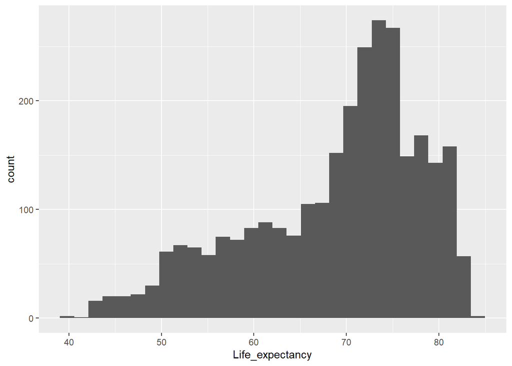

```r
# Histogram
ggplot(life_data, aes(x = Life_expectancy)) + geom_histogram(fill = "blue") + stat_bin(bins=30)
```

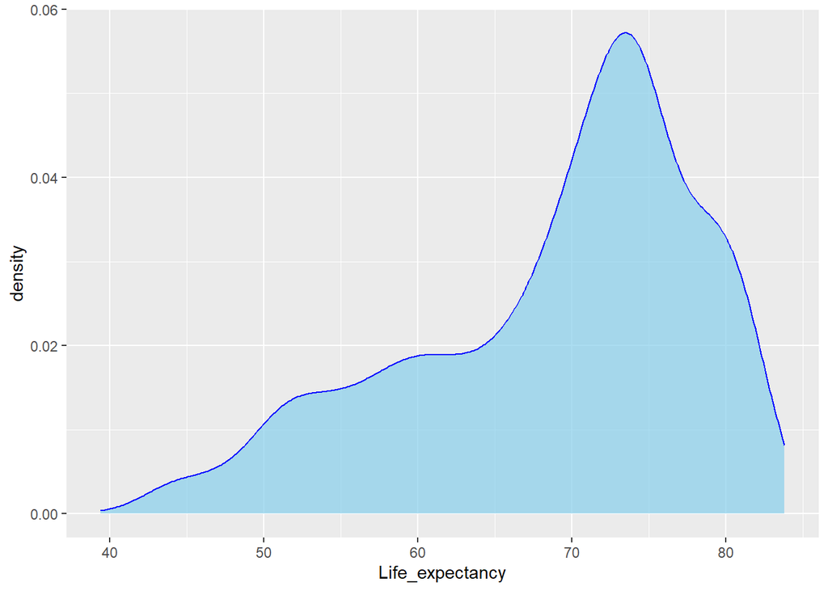

```r
ggplot(life_data, aes(x = Life_expectancy)) +
  geom_density(fill = "skyblue", color = "blue", alpha = 0.7)
```

We have a left skewed distribution as we have a negative skewness and Mode>Median>Mean. We can see it clear also in the graphs.

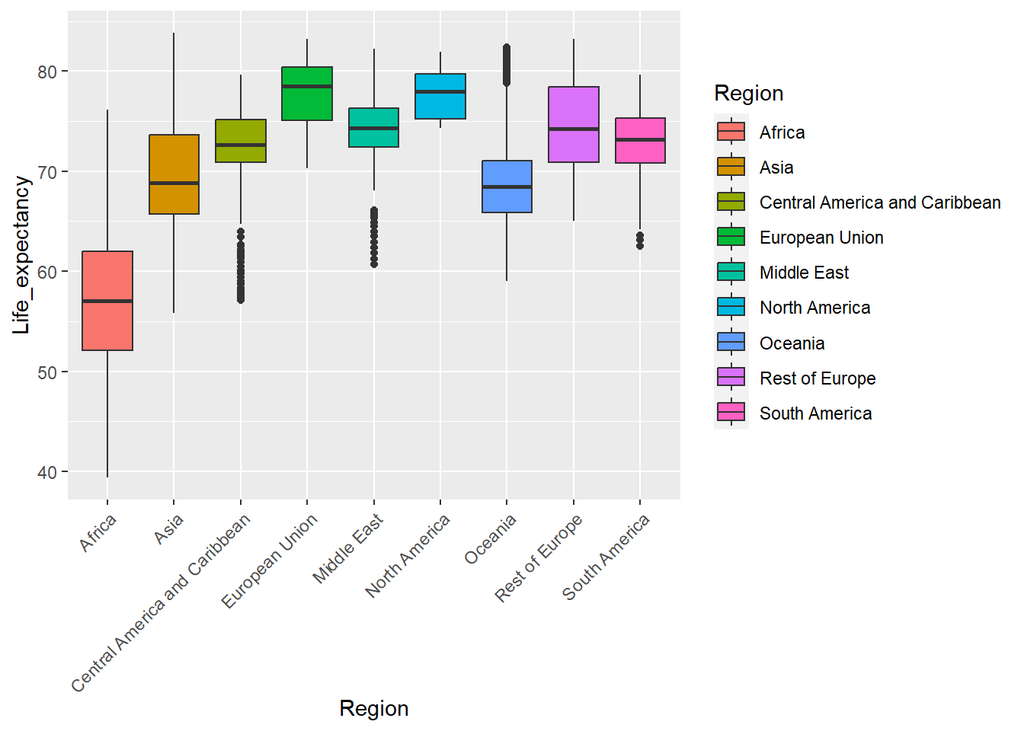

```r
# Boxplot
ggplot(life_data, aes(x = Region, y = Life_expectancy)) +
  geom_boxplot(aes(fill = Region)) +
  theme(axis.text.x = element_text(angle = 45, hjust = 1))
```

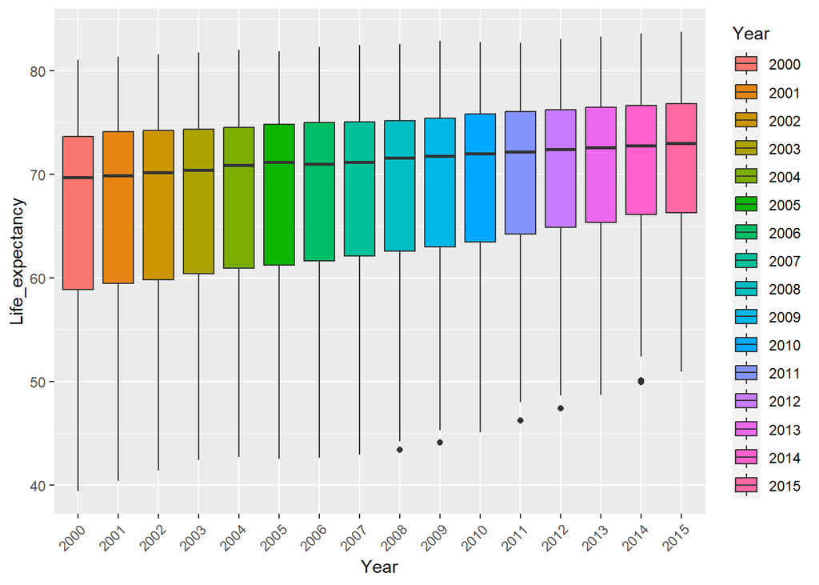

```r
# Change type of the column Year
life_data$Year <- as.factor(life_data$Year)
# Boxplot by Year
ggplot(life_data, aes(x = Year, y = Life_expectancy)) +
  geom_boxplot(aes(fill = Year)) +
  theme(axis.text.x = element_text(angle = 45, hjust = 1))
```

```r
life_data %>% group_by(Year) %>% slice(which.min(Life_expectancy))
```

```
## # A tibble: 16 × 22
## # Groups:   Year [16]
##    Region Country   Year  Infant_deaths Under_five_deaths Thinness_ten_ninetee…¹
##    <chr>  <chr>     <fct>         <dbl>             <dbl>                  <dbl>
##  1 Africa Sierra L… 2000          138.              225.                     1.3
##  2 Africa Sierra L… 2001          136.              219.                     1.1
##  3 Africa Sierra L… 2002          133.              214.                     9.9
##  4 Africa Sierra L… 2003          130.              208.                     9.7
##  5 Africa Eswatini  2004           69.1             120.                     7.7
##  6 Africa Eswatini  2005           68.3             119.                     7.3
##  7 Africa Lesotho   2006           74.5             116.                     8.8
##  8 Africa Lesotho   2007           73.8             114.                     8.4
##  9 Africa Lesotho   2008           77.1             113                      8
## 10 Africa Lesotho   2009           73.6             104.                     7.6
## 11 Africa Lesotho   2010           70.9              96.4                    7.2
## 12 Africa Lesotho   2011           69                93.9                    6.8
## 13 Africa Lesotho   2012           70.2              92.7                    6.4
## 14 Africa Lesotho   2013           71                92.6                    6.1
## 15 Africa Lesotho   2014           71.9              94.2                    5.8
## 16 Africa Central … 2015           87.9             123.                     8.2
## # ℹ abbreviated name: ¹Thinness_ten_nineteen_years
## # ℹ 16 more variables: Thinness_five_nine_years <dbl>, Schooling <dbl>,
## #   Incidents_HIV <dbl>, Economy_status_Developed <int>,
## #   Economy_status_Developing <int>, Life_expectancy <dbl>, Population <dbl>,
## #   GDP <dbl>, Economy_status <fct>, Polio <dbl>, Measles <dbl>,
## #   Adult_mortality <dbl>, Alcohol <dbl>, Diphtheria <dbl>, HepatitisB <dbl>,
## #   Mean_BMI <dbl>
```

We can see that all the minimum by year Life expectancies come from Developing countries. Some of them are outliers. More investigation about outliers later.

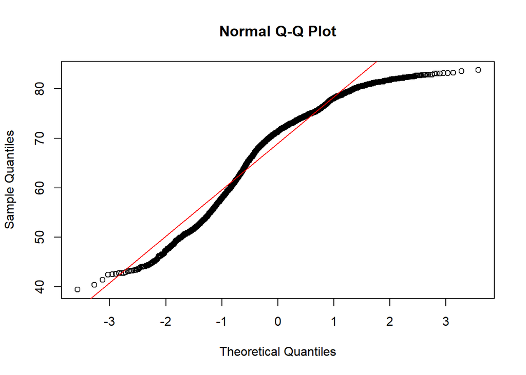

```r
# Checks for Normality
qqnorm(life_data$Life_expectancy)
qqline(life_data$Life_expectancy, col = "red")
```

```r
shapiro.test(life_data$Life_expectancy)
```

```
##
##  Shapiro-Wilk normality test
##
## data:  life_data$Life_expectancy
## W = 0.93497, p-value < 2.2e-16
```

```r
lillie.test(life_data$Life_expectancy)
```

```
##
##  Lilliefors (Kolmogorov-Smirnov) normality test
##
## data:  life_data$Life_expectancy
## D = 0.11612, p-value < 2.2e-16
```

As expected from the histogram, the density graph and the QQ-plot we can confirm that our respone variables does not follow Normal Distribution. On both Shapiro and Lilliefors tests we reject the Null Hypothesis (p-value<0.05, with alpha=0.05 the significance level). The Null Hypothesis says that it follows a Normal Distribution.

This deviation from normality is important to consider in the next steps of our statistical analyses and model selection. That’s why, we will try to make the distribution of our response variable at least roughly Normal.

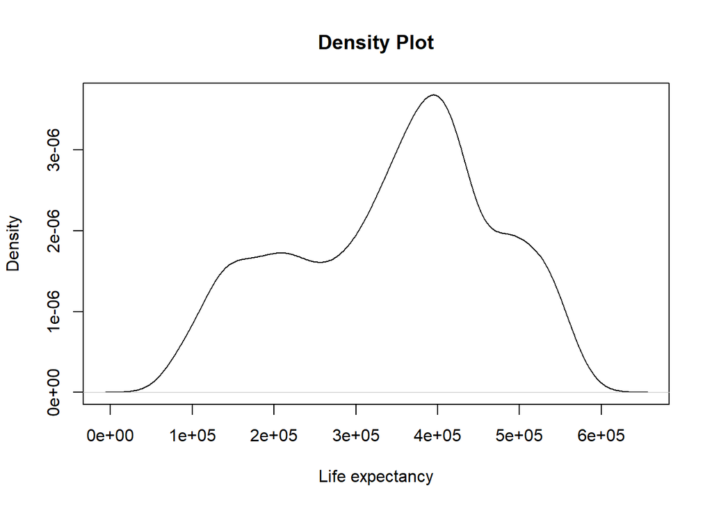

```r
# Try to normalize our curve
life_data$transformed_variable <- life_data$Life_expectancy^3
# Plotting the density of the transformed variable to check for normality
plot(density(life_data$transformed_variable), main="Density Plot", xlab="Life expectancy")
```

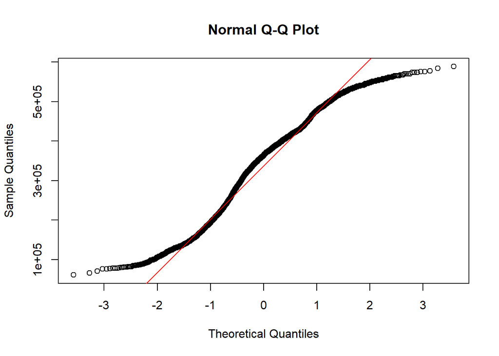

```r
qqnorm(life_data$transformed_variable)
qqline(life_data$transformed_variable, col = "red")
```

```r
shapiro.test(life_data$transformed_variable) # as expected from histogram
```

```
##
##  Shapiro-Wilk normality test
##
## data:  life_data$transformed_variable
## W = 0.96944, p-value < 2.2e-16
```

```r
lillie.test(life_data$transformed_variable)
```

```
##
##  Lilliefors (Kolmogorov-Smirnov) normality test
##
## data:  life_data$transformed_variable
## D = 0.068931, p-value < 2.2e-16
```

```r
life_data$transformed_variable <- NULL
```

Still, we don’t have Normality, but we can see an improvement on both density graph and QQ-plot. After trying many transformations we selected $\text{Life_expectancy}^3$.

```r
train_set$Life_expectancy <- train_set$Life_expectancy^3
```

We continue with the EDA of our predictors.

Economy status

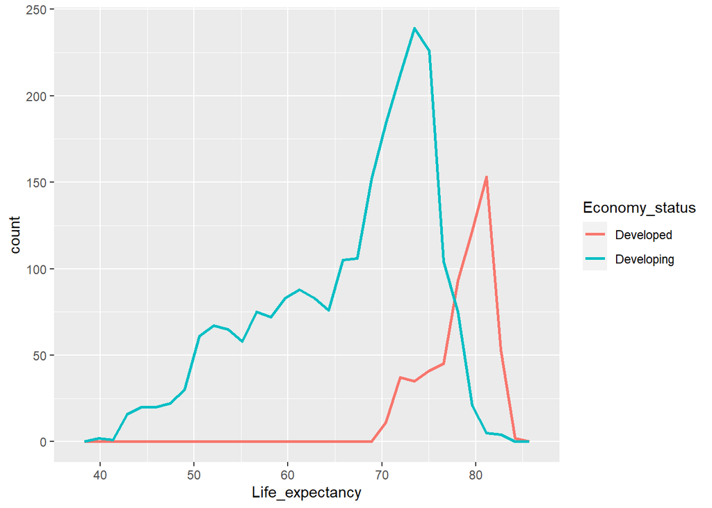

```r
# Graphs
ggplot(data = life_data, mapping = aes(x = Life_expectancy,
                                       colour = Economy_status)) + geom_freqpoly(size = 1)
```

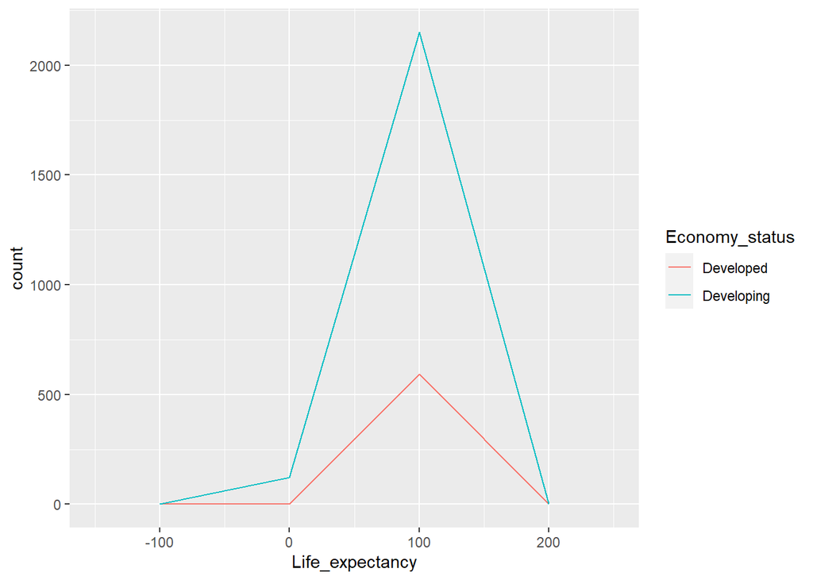

```r
# Same as the graphs Above
ggplot(data = life_data, mapping = aes(x = Life_expectancy, colour = Economy_status)) +
  geom_freqpoly(binwidth = 100)
```

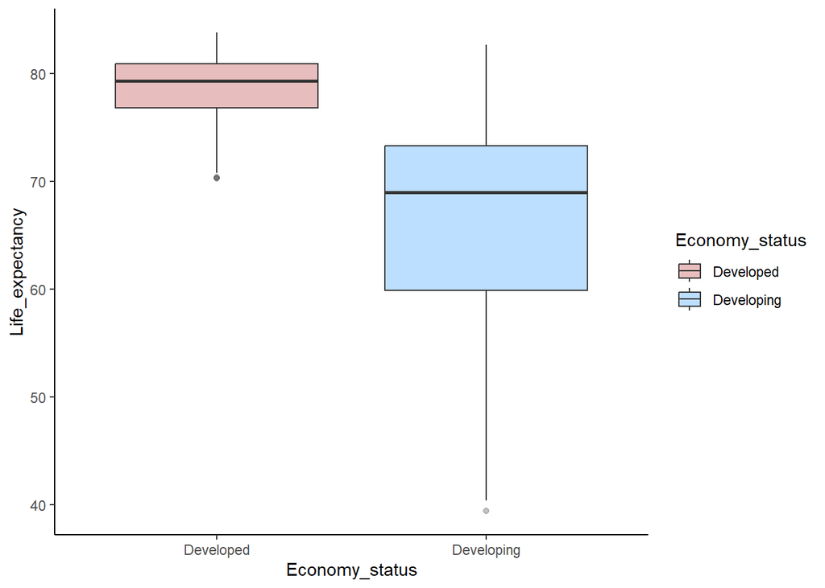

```r
ggplot(data = life_data, aes(x = Economy_status, y = Life_expectancy, fill = Economy_status)) +
  geom_boxplot(alpha=.3) +
  theme_classic() +
  scale_fill_manual(values = c("firebrick", "dodgerblue"))
```

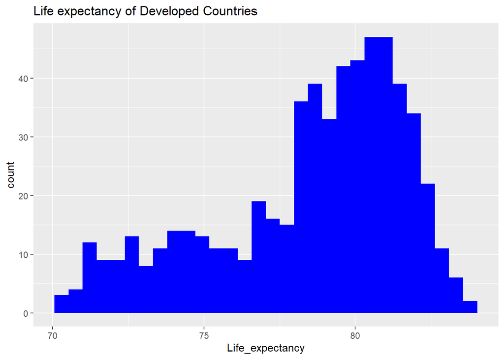

```r
developed.life.exp <- life_data$Life_expectancy[life_data$Economy_status == "Developed"]
developing.life.exp <- life_data$Life_expectancy[life_data$Economy_status == "Developing"]

ggplot(life_data %>% filter(Economy_status == "Developed"), aes(x = Life_expectancy)) +
  geom_histogram(fill = "blue") + ggtitle("Life expectancy of Developed Countries")
```

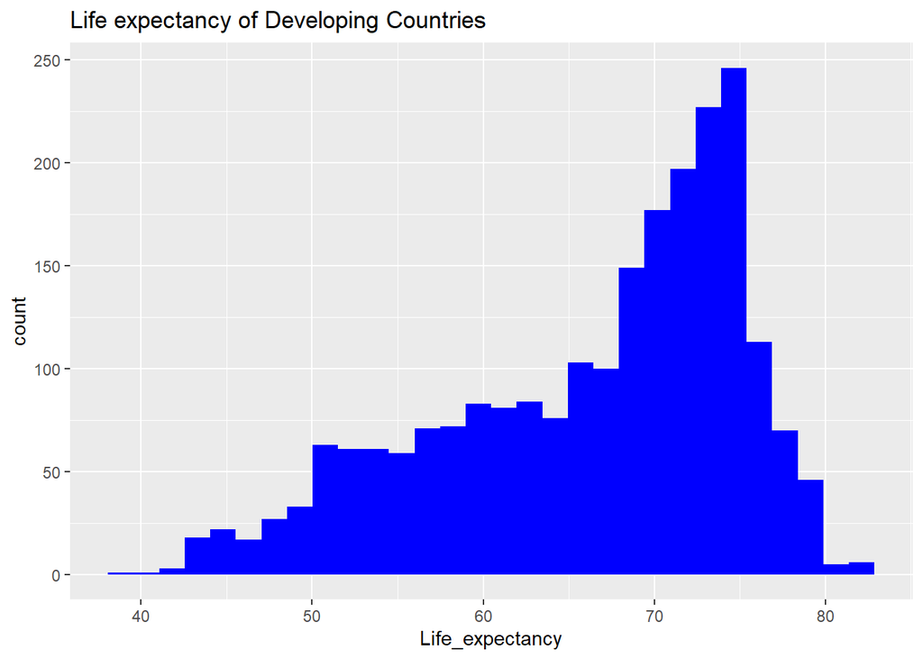

```r
ggplot(life_data %>% filter(Economy_status == "Developing"), aes(x = Life_expectancy)) +
  geom_histogram(fill = "blue") +  ggtitle("Life expectancy of Developing Countries")
```

From the above graphs we can see that the people from Developed countries seem to have higher Life expectancy compare to people who come from Developing countries. We can also observe that we have more people from developing countries than people from developed. One way to see the proportion is the following.

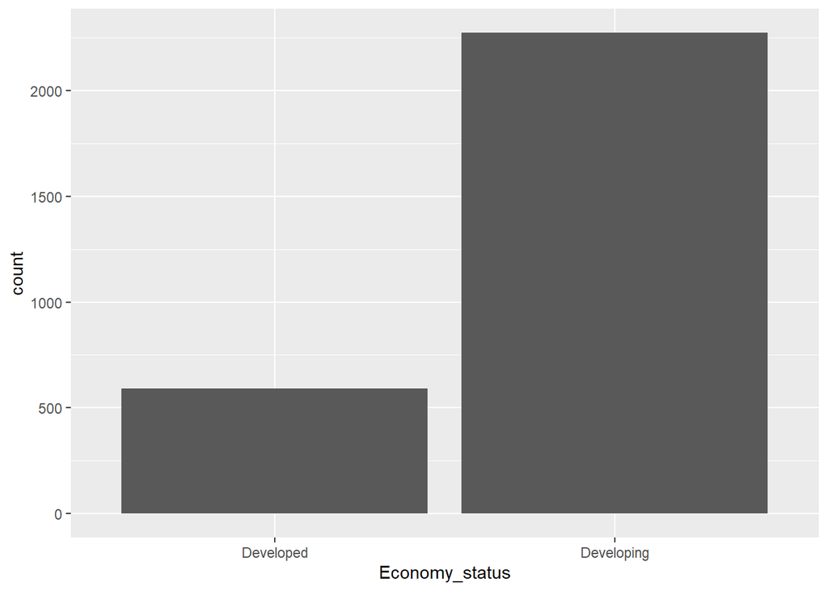

```r
ggplot(data = life_data, mapping = aes(x = Economy_status)) + geom_bar()
```

```r
# Percentage of People from Developed countries
sum(life_data$Economy_status_Developed)/nrow(life_data)
```

```
## [1] 0.2067039
```

```r
# Proportion developed compare to developing
sum(life_data$Economy_status_Developed)/sum(life_data$Economy_status_Developing)
```

```
## [1] 0.2605634
```

The people from Developing countries are 4 times the people from Developed countries in our dataset.

We want to check with hypotheses tests that indeed the Life expectancy is higher for people from Developed countries compare to people from Developing countries. To be able to be sure for the results of t-test we should check the normality.

```r
mean_dif <- mean(developed.life.exp) - mean(developing.life.exp)
mean_dif
```

```
## [1] 12.16402
```

```r
# Checks for normality
shapiro.test(developed.life.exp)
```

```
##
##  Shapiro-Wilk normality test
##
## data:  developed.life.exp
## W = 0.92116, p-value < 2.2e-16
```

```r
lillie.test(developed.life.exp)
```

```
##
##  Lilliefors (Kolmogorov-Smirnov) normality test
##
## data:  developed.life.exp
## D = 0.11832, p-value < 2.2e-16
```

```r
shapiro.test(developing.life.exp)
```

```
##
##  Shapiro-Wilk normality test
##
## data:  developing.life.exp
## W = 0.93118, p-value < 2.2e-16
```

```r
lillie.test(developing.life.exp)
```

```
##
##  Lilliefors (Kolmogorov-Smirnov) normality test
##
## data:  developing.life.exp
## D = 0.121, p-value < 2.2e-16
```

```r
# Welch's t-test
t.test(developed.life.exp, developing.life.exp, alternative="greater")
```

```
##
##  Welch Two Sample t-test
##
## data:  developed.life.exp and developing.life.exp
## t = 53.685, df = 2623.8, p-value < 2.2e-16
## alternative hypothesis: true difference in means is greater than 0
## 95 percent confidence interval:
##  11.79119      Inf
## sample estimates:
## mean of x mean of y
##  78.50574  66.34173
```

From both shapiro and lillieforse test we reject the Null Hypotheses so the variables doesn’t follow Normal distribution. The t-test suggests that the mean of Life expectancy developed is greater than the mean of Life expectancy developing as we reject the Null Hypothesis for a significance level alpha=0.05 (p-value<0.05). Despite the result of the t-test we will do a permutation test because t-test assumes that the variables follow a Normal Distribution and here it is not the case.

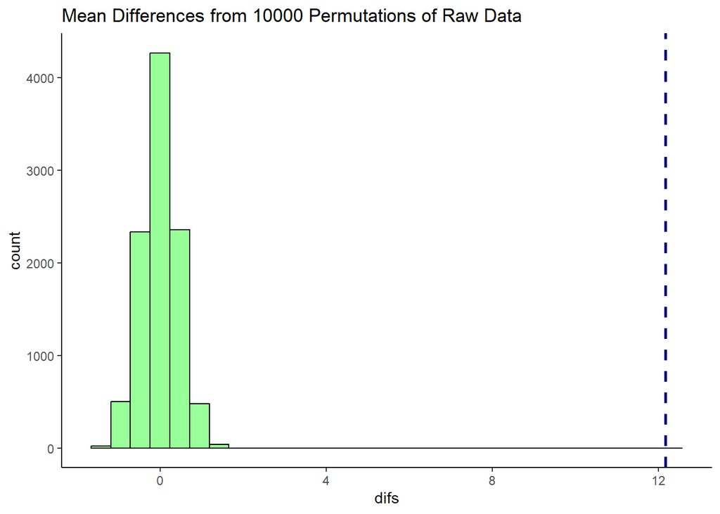

```r
set.seed(3) # for reproducibility
all_countries <- c(developed.life.exp, developing.life.exp)
results<-vector('list',10000)
for(i in 1:10000){
  x <- split(sample(all_countries), rep(1:2, c(length(developed.life.exp), length(developing.life.exp))))
  results[[i]]<-mean(x[[1]]) - mean(x[[2]])
}
df <- data.frame(difs = unlist(results))
ggplot(df, aes(x=difs)) +
  geom_histogram(color="black", fill="green", alpha=.4) +
  geom_vline(color="navy",lwd=1,lty=2,xintercept = mean_dif) +
  theme_classic()+
  ggtitle("Mean Differences from 10000 Permutations of Raw Data")
```

```r
sum(unlist(results) > mean_dif) /10000
```

```
## [1] 0
```

For the permutation test, we reject the Null Hypothesis (p-value=0<0.05) so we have that indeed the mean of Life expectancy of people from Developed countries is greater than the Life expectancy of people from Developing countries.

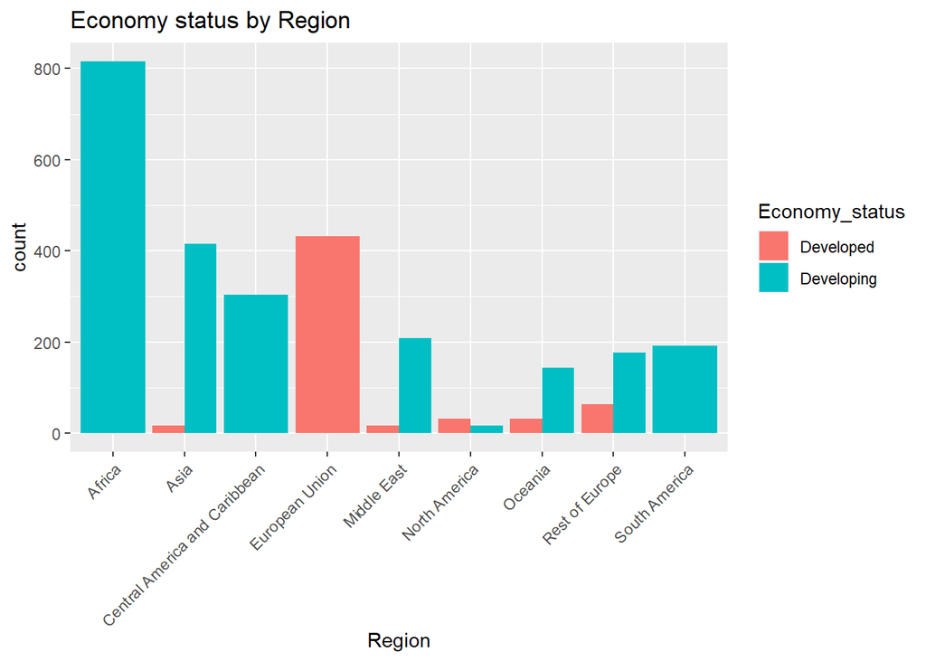

```r
ggplot(life_data, aes(x = Region, fill = Economy_status)) +
  geom_bar(position = "dodge") +
  ggtitle("Economy status by Region") +
  theme(axis.text.x = element_text(angle = 45, hjust = 1))
```

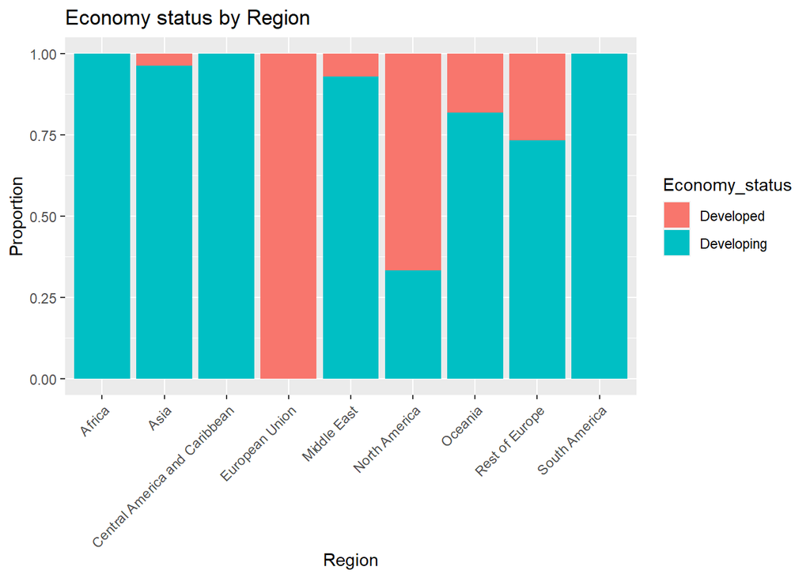

```r
ggplot(life_data, aes(x = Region, fill = Economy_status)) +
  geom_bar(position = "fill") +
  ggtitle("Economy status by Region") +
  labs(y="Proportion") +
  theme(axis.text.x = element_text(angle = 45, hjust = 1))
```

From the 2 graphs we see that all European Union countries are developed and all Africa, Central America and Caribbean and South America countries are developing. From the first graph we observe that we have the highest number of countries in the Africa Region.

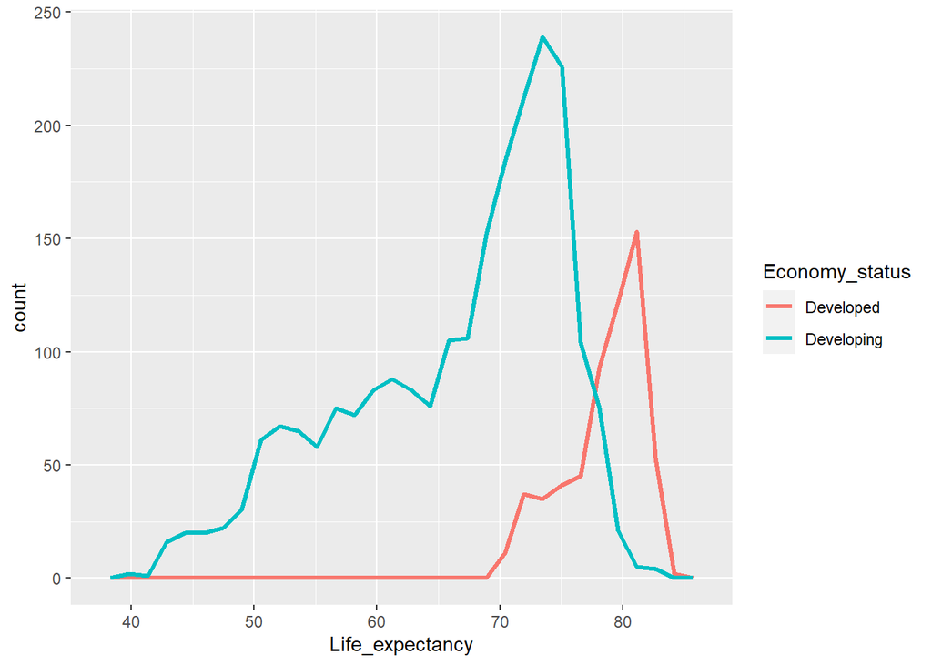

```r
ggplot(data = life_data, mapping = aes(x = Life_expectancy,
                                       colour = Economy_status)) + geom_freqpoly(size = 1.2)
```

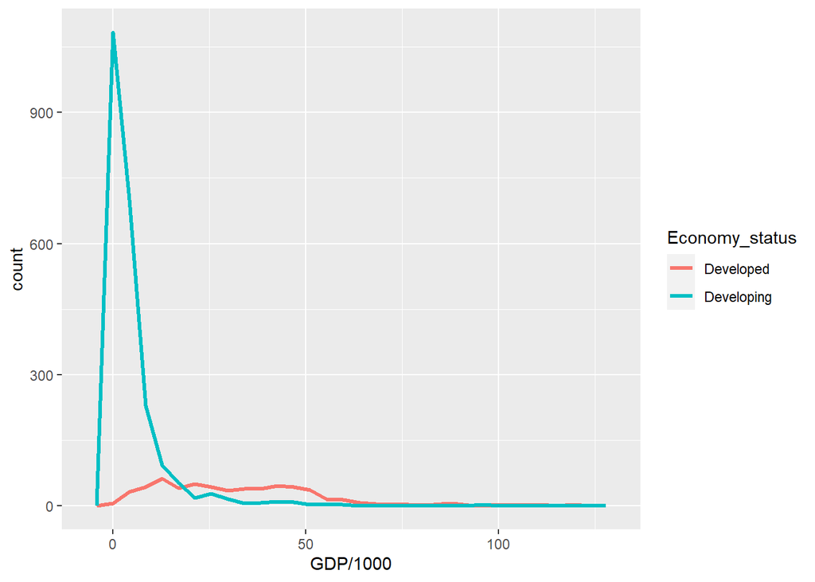

```r
ggplot(data = life_data, mapping = aes(x = GDP/1000,
                                       colour = Economy_status)) + geom_freqpoly(size = 1.2)
```

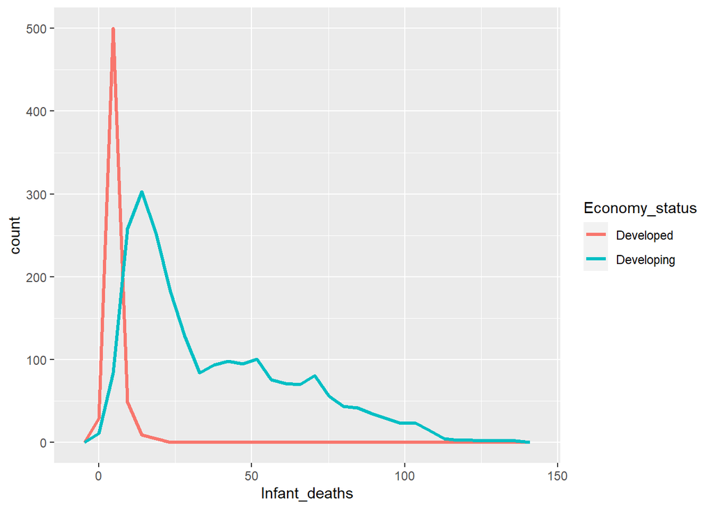

```r
ggplot(data = life_data, mapping = aes(x = Infant_deaths,
                                       colour = Economy_status)) + geom_freqpoly(size = 1.2)
```

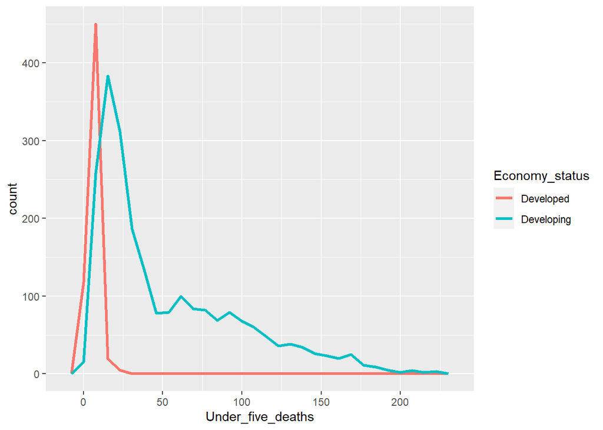

```r
ggplot(data = life_data, mapping = aes(x = Under_five_deaths,
                                       colour = Economy_status)) + geom_freqpoly(size = 1.2)
```

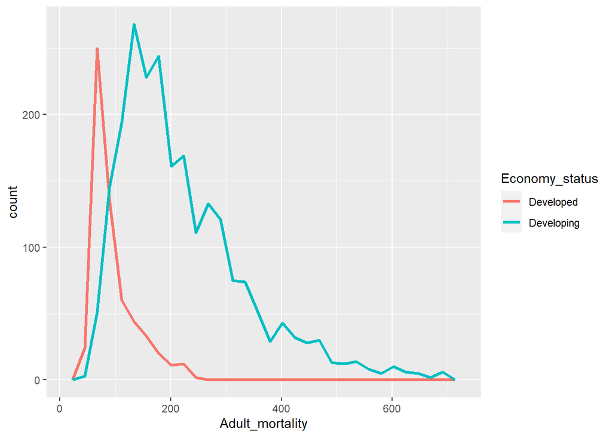

```r
ggplot(data = life_data, mapping = aes(x = Adult_mortality,
                                       colour = Economy_status)) + geom_freqpoly(size = 1.2)
```

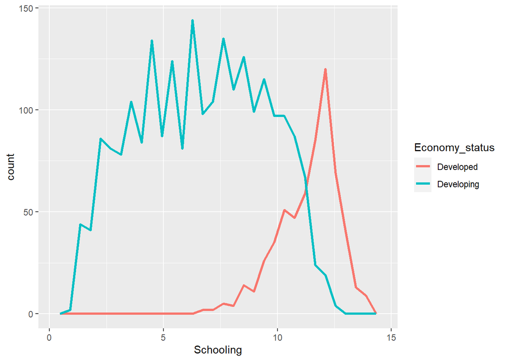

```r
ggplot(data = life_data, mapping = aes(x = Schooling,
                                       colour = Economy_status)) + geom_freqpoly(size = 1.2)
```

From the above graphs we see that many of our predictors are affected by the Economy status or vice versa.

Region

```r
unique(life_data$Region)
```

```
## [1] "Asia"                          "South America"
## [3] "Middle East"                   "Central America and Caribbean"
## [5] "European Union"                "Rest of Europe"
## [7] "Africa"                        "Oceania"
## [9] "North America"
```

```r
life_data[which(life_data$Life_expectancy==max(life_data$Life_expectancy)), 1] # Region
```

```
## [1] "Asia"
```

```r
life_data[which(life_data$Life_expectancy==max(life_data$Life_expectancy)), 2] # Country
```

```
## [1] "Japan"
```

```r
life_data[which(life_data$Life_expectancy==min(life_data$Life_expectancy)), 1] # Region
```

```
## [1] "Africa"
```

```r
life_data[which(life_data$Life_expectancy==min(life_data$Life_expectancy)), 2] # Country
```

```
## [1] "Sierra Leone"
```

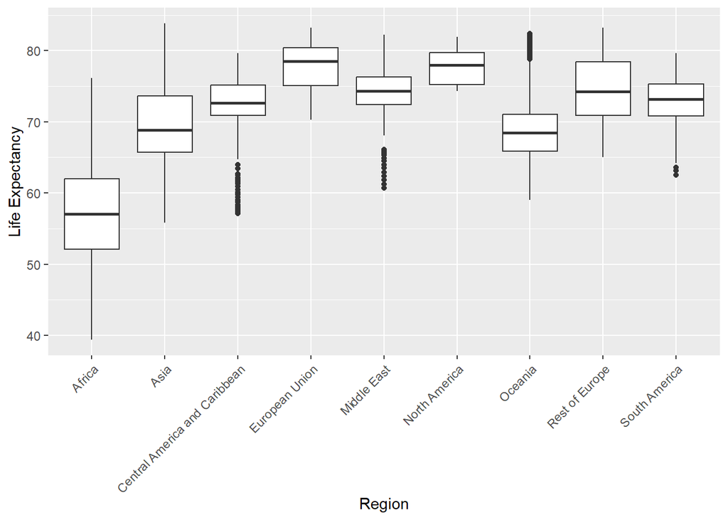

```r
# Boxplot
ggplot(data = life_data, mapping = aes(x = Region, y = Life_expectancy)) + geom_boxplot() +
  labs(y="Life Expectancy", x="Region") + theme(axis.text.x = element_text(angle = 45, hjust = 1))
```

From the boxplot we can understand that the Region is important variable because it affects a lot the Life expectancy.

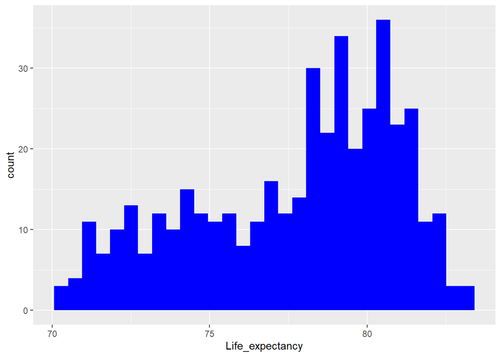

```r
# Histograms
ggplot(life_data %>% filter(Region == "European Union"), aes(x = Life_expectancy)) +
  geom_histogram(fill = "blue")
```

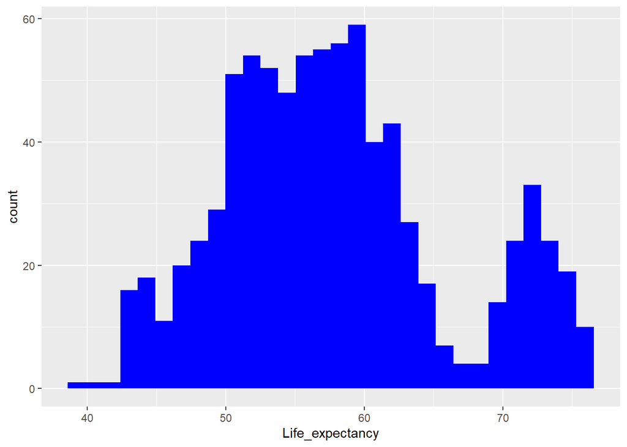

```r
ggplot(life_data %>% filter(Region == "Africa"), aes(x = Life_expectancy)) +
  geom_histogram(fill = "blue")
```

Alcohol

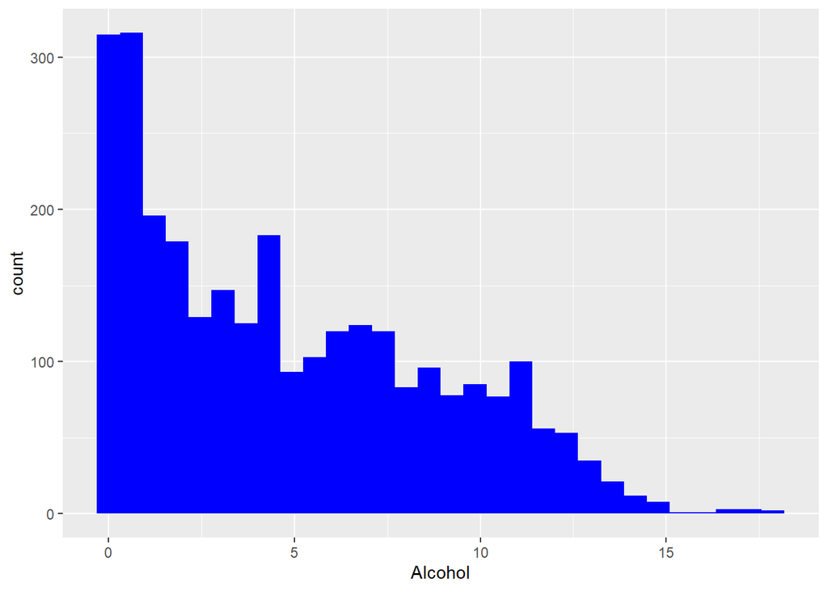

```r
# Histogram
ggplot(life_data, aes(x = Alcohol)) + geom_histogram(fill = "blue")
```

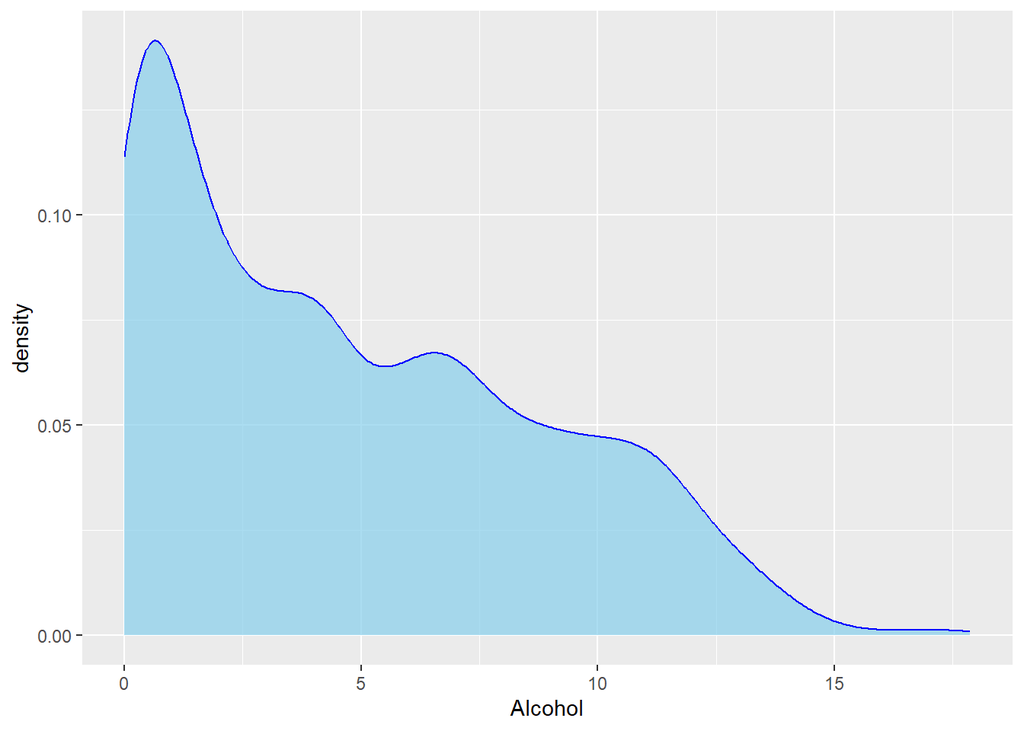

```r
ggplot(life_data, aes(x = Alcohol)) +
  geom_density(fill = "skyblue", color = "blue", alpha = 0.7)
```

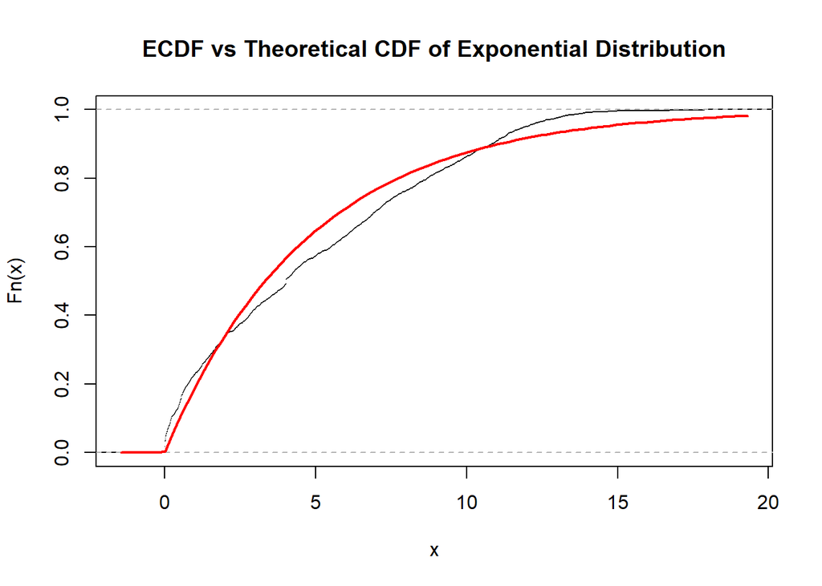

```r
# ECDF plot
plot(ecdf(life_data$Alcohol), main="ECDF vs Theoretical CDF of Exponential Distribution")
curve(pexp(x, rate=1/mean(life_data$Alcohol)), add=TRUE, col='red', lwd=2)
```

From the graphs we see that Alcohol follows a right-skewed distribution and we would like to check if it follows an exponential distribution with $\lambda = \frac{1}{\mu_{\text{Alcohol}}}$.

```r
mean(life_data$Alcohol)
```

```
## [1] 4.80626
```

```r
# Perform Kolmogorov Smirnov test
lambda <- 1 / mean(life_data$Alcohol)
ks.test(life_data$Alcohol, "pexp", rate = lambda)
```

```
##
##  Asymptotic one-sample Kolmogorov-Smirnov test
##
## data:  life_data$Alcohol
## D = 0.083933, p-value < 2.2e-16
## alternative hypothesis: two-sided
```

We reject the Null hypothesis so the Alcohol does not follow Exp($\frac{1}{\mu_{\text{Alcohol}}}$).

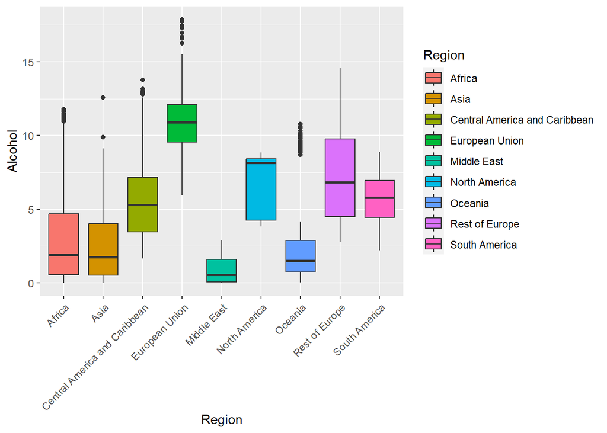

```r
# Boxplot with Region
ggplot(life_data, aes(x = Region, y = Alcohol, fill = Region)) +
  geom_boxplot() + theme(axis.text.x = element_text(angle = 45, hjust = 1))
```

The Alcohol consumptions seems to differ for each Region. European Union has the highest median.

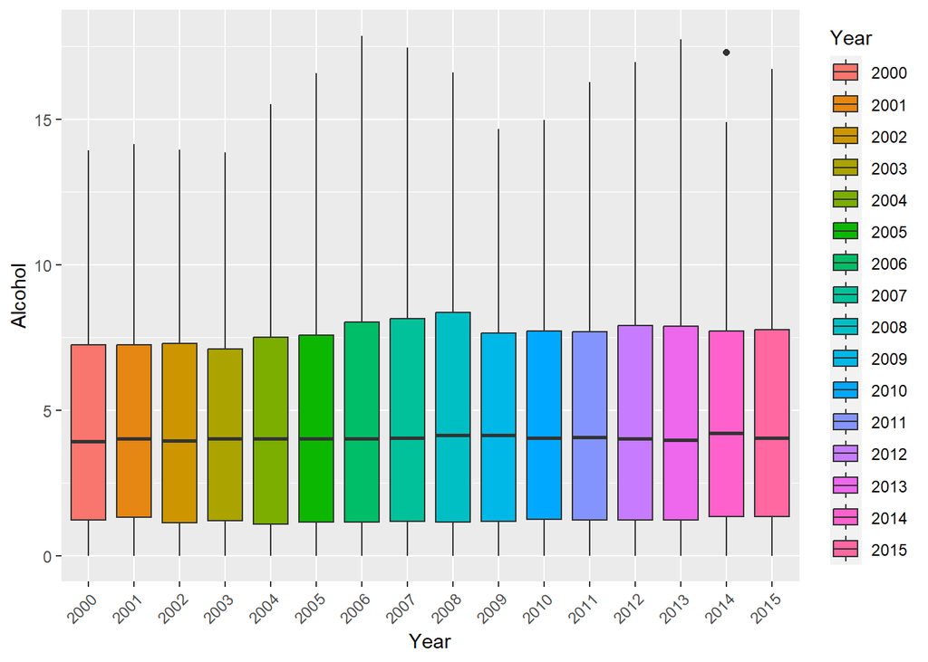

```r
# Boxplot with Year
ggplot(life_data, aes(x = Year, y = Alcohol, fill = Year)) +
  geom_boxplot() + theme(axis.text.x = element_text(angle = 45, hjust = 1))
```

```r
# Check from which Country and how much is the outlier
filter(life_data, Year == 2014)[which(filter(life_data, Year == 2014)$Alcohol==max(filter(life_data, Year == 2014)$Alcohol)), 2]
```

```
## [1] "Estonia"
```

```r
max(life_data$Alcohol[life_data$Year == 2014])
```

```
## [1] 17.29
```

Diphtheria

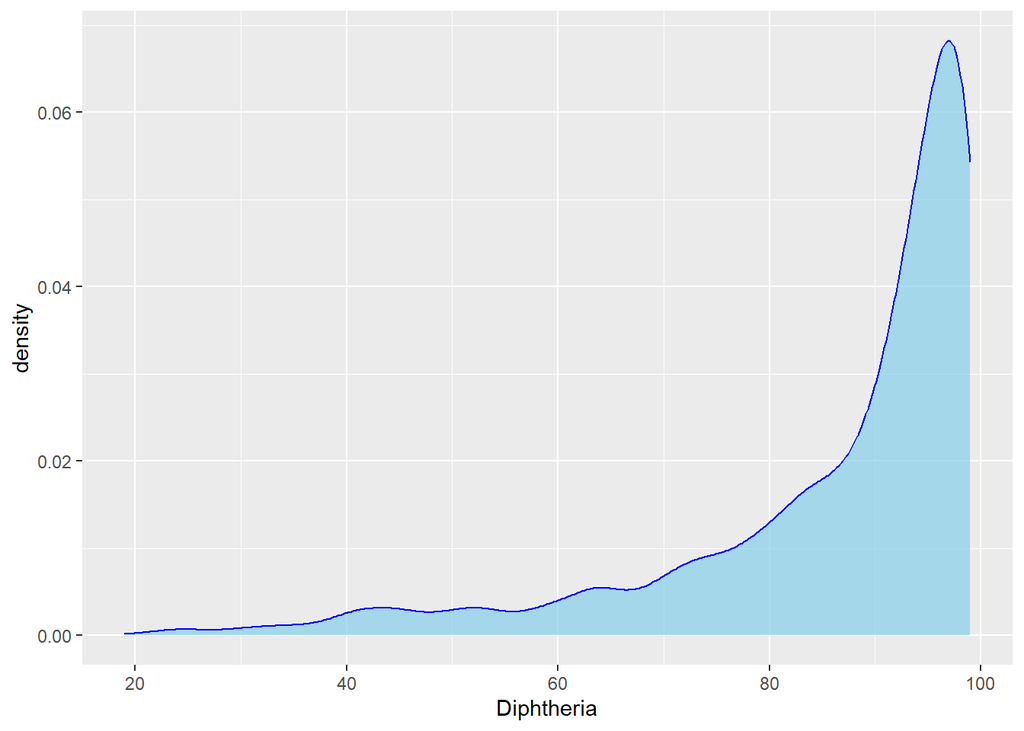

```r
ggplot(life_data, aes(x = Diphtheria)) +
  geom_density(fill = "skyblue", color = "blue", alpha = 0.7)
```

HepatitisB